# LOGISTIC REGRESSION

Nguyen Hai Truong

March 1, 2017

**Mục tiêu nghiên cứu:**

Nghiên cứu khung lý thuyết mô hình hồi quy Logistic và cách thực hành mô hình với bộ số liệu có sẵn trong R.

# 1 Hồi quy Logistic

## 1.1 Khái niệm cơ bản

Trước hết, ta cần định nghĩa một số khái niệm cơ bản sau.

- **Biến định tính (qualitative variable)**: là biến cho biết có hay không có một thuộc tính nào đó. Biến định tính có thể có 2 phạm trù (trạng thái) hoặc nhiều hơn thế. Ví dụ: biến giới tính (nam, nữ); biến chất lượng sản phẩm (chính phẩm, phế phẩm); biến vùng-miền (Bắc, Trung, Nam); biến trình độ học vấn (Tốt nghiệp cấp 3, Đại học, Thạc sỹ, Tiến sỹ) v.v.
- **Biến giả (dummy variable)**: biến chỉ nhận hai giá trị 0-1, dùng để biểu diễn biến định tính.

Giả sử biến định tính Z nào đó có 2 phạm trù, sử dụng biến số nhận giá trị 1 ứng với các quan sát thuộc một trong hai phạm trù và nhận giá trị 0 cho phạm trù còn lại. Biến số nhận giá trị 0-1 này gọi là biến giả tương ứng với biến định tính Z. Chúng ta có thể chọn hai giá trị khác biệt bất kỳ để gán cho hai nhóm khác nhau của biến định tính mà không làm thay đổi bản chất và kết luận của vấn đề nghiên cứu.

## 1.2 Binary Logistic Regression

(gọi tắt là hồi quy Logistic)

Là mô hình hồi quy khi biến phụ thuộc là biến định tính chỉ gồm 2 trạng thái, ta sử dụng biến giả để biểu diễn biến phụ thuộc. Như vậy, biến phụ thuộc chỉ nhận hai giá trị 0 và 1.

Mô hình hồi quy này giúp ta có thể dự báo được xác suất khi biến phụ thuộc nhận giá trị 1 (xác suất biến cố xảy ra) dựa vào thông tin các biến độc lập trong mô hình, để sau đó phân loại trạng thái của biến phụ thuộc.

Xác suất: ký hiệu là P.

Đặt:

p = P(Y=1/Xj) - xác suất khi biến phụ thuộc Y nhận giá trị 1 (xác suất biến cố xảy ra); j=1,…,n

(1-p) = 1-P(Y=1/Xj) = P(Y=0/Xj) - xác suất khi Y=0 (xác suất biến cố không xảy ra)

**Làm thế nào để mô hình hóa được mối quan hệ giữa xác suất khi Y nhận giá trị 1 (p) và các biến độc lập (Xj)?**

Giả sử ta sử dụng mô hình hồi quy tuyến tính thông thường (linear regression):
$$p = B_0 + B_1X_1 + ... + B_nX_n$$
Ta nhận thấy việc chạy mô hình sẽ có thể gặp phải vấn đề: Với Xj nhận giá trị nhỏ gần tới 0, p có thể < 0; còn với Xj nhận giá trị lớn, p có thể > 1. Như vậy những ước lượng trên sẽ không chính xác vì p là xác suất nên chỉ nhận giá trị từ 0 đến 1. Hồi quy tuyến tính sẽ không còn thích hợp trong trường hợp này nữa.

Để giải quyết vấn đề trên, trong hồi quy Logistic người ta sử dụng hàm Logistic trong toán học (**logistic function**):

$$p_=\frac{exp(B_0 + B_1X_1 + ... + B_nX_n)}{1+exp(B_0 + B_1X_1 + ... + B_nX_n)}$$

=>
$$1-p=\frac{1}{1+exp(B_0 + B_1X_1 + ... + B_nX_n)}$$

=>
$$\frac{p}{1-p}=exp(B_0 + B_1X_1 + ... + B_nX_n)$$

Tỷ số trên được gọi là **Odds** (“khả năng”, “tỷ lệ ưu thế”) - cho biết xác suất khi Y=1 (xác suất biến cố xảy ra) bằng bao nhiêu lần so với xác suất khi Y=0 (xác suất biến cố không xảy ra). Ví dụ, tỷ lệ hộ nghèo của một địa phương là 0.25, khi đó tỷ lệ hộ không thuộc hộ nghèo sẽ là 0.75 => Odds = 1/3 - xác suất hộ nghèo bằng 1/3 so với xác suất hộ không thuộc diện hộ nghèo.

=>
$$Ln(Odds)=Ln(\frac{p}{1-p}) = B_0 + B_1X_1 + ... + B_nX_n$$

Phương trình trên gọi là **phương trình hồi quy Logistic**. Đây là một dạng hàm Logit, Ln(Odds) là hàm hồi quy tuyến tính với các biến độc lập Xj (Ln: logarit cơ số e, e~2.71).

Để ước lượng các tham số Bj, người ta dùng phương pháp hợp lý tối đa (**maximum likelihood**), nghĩa là tìm Bj để tối đa hóa hàm hợp lý.

Hàm hợp lý có dạng:

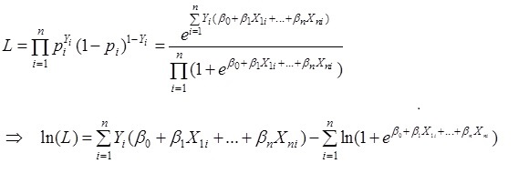

Như vậy, bài toán ở đây là: Tìm Bj để L -> max <=> Tìm Bj để ln(L) -> max

Khi ước lượng được các tham số Bj, với mỗi tập giá trị Xj cụ thể ta có thể dễ dàng tính được giá trị ước lượng của pi (theo công thức đã đề cập ở trên). Từ đó ta có thể phân loại được trạng thái của biến phụ thuộc dựa vào việc so sánh giá trị ước lượng pi và ngưỡng giá trị ta chọn để phân loại.

Ngoài ra, khi ta có giá trị ước lượng của Bj và pi, có thể xác định được nếu Xj tăng 1 đơn vị thì xác suất pi sẽ thay đổi như thế nào, hay nói cách khác **ảnh hưởng của Xj đến pi** được thể hiện qua công thức sau:

$$\frac{∂p_i}{∂X_j} = p_i(1-p_i)B_j$$

**Để xác suất p là 50% thì các biến độc (Xj) có mối liên hệ như thế nào?**

$$p=\frac{exp(B_0 + B_1X_1 + ... + B_nX_n)}{1+exp(B_0 + B_1X_1 + ... + B_nX_n)} = \frac{1}{2}$$
<=>
$$exp(B_0 + B_1X_1 + ... + B_nX_n) = 1$$

<=>
$$B_0 + B_1X_1 + ... + B_nX_n = 0$$

Phương trình trên thể hiện mối liên hệ giữa các biến độc lập Xj khi p = 50%.

## 1.3 Đánh giá chất lượng mô hình

**Confusion matrix** dùng để xác định xem bao nhiêu quan sát được phân loại đúng và bao nhiêu quan sát phân loại sai, hay nói cách khác confusion matrix so sánh trạng thái được dự báo với trạng thái thực tế của biến phụ thuộc.

Dùng confusion matrix có thể tính được **accuracy** (độ chính xác của mô hình) - tỷ lệ tổng số quan sát được dự báo đúng trên tổng quan sát. Ngoài ra, còn có thể tính được:

- True positive rate (TPR), sensitivity: % biến cố Y=1 trong thực tế được dự báo đúng
- False negative rate (FNR): % biến cố Y=1 trong thực tế dự báo sai
- True negative rate (TNR), specificity: % biến cố Y=0 trong thực tế được dự báo đúng
- False positive rate (FPR), 1-specificity: % biến cố Y=0 trong thực tế dự báo sai (thực tế là Y=0 nhưng dự báo là Y=1)
- Precison = PPV (positive predicted value): trong số quan sát được dự báo là Y=1 có bao nhiêu % quan sát được dự báo đúng

**ROC** (“Receiver Operating Characteristic”) **curve** khái quát chất lượng mô hình bằng việc biểu thị mối quan hệ giữa true positive rate (sensitivity) và false positive rate (1-specificity) tương ứng với mỗi ngưỡng phân loại khác nhau.

Ta diễn giải chi tiết cách vẽ đường ROC như sau: Giả sử ta muốn xem 1 KH có khả năng trả nợ hay không, biến phụ thuộc là KH có 2 trạng thái là “vỡ nợ”(=1) và “không vỡ nợ” (=0). Sử dụng hồi quy Logistic ta dự báo được xác suất vỡ nợ của KH, sau đó ta chọn giá trị ngưỡng để phân loại trạng thái KH (Ví dụ: pi > 0.5 - KH “vỡ nợ”; pi <= 0.5 - KH “không vỡ nợ” => như vậy ngưỡng ở đây ta chọn là 0.5). Ứng với mỗi giá trị ngưỡng khác nhau sẽ là 1 điểm có tọa độ (false positive rate, true positive rate). Tập hợp các điểm này (tức với những sự lựa chọn ngưỡng khác nhau) sẽ tạo thành đường ROC.

Đường ROC nằm càng hướng về phía đỉnh góc bên trái thì độ chính xác của dự báo càng cao, điều đó thể hiện true positive rate cao và false positive rate thấp; còn nếu càng tiến tới đường chéo 45 độ so với trục hoành thì độ chính xác của dự báo càng kém. Đường chéo 45 độ so với trục hoành thể hiện sự phân loại là không có ý nghĩa (do true positive rate = false positive rate).

**AUC** (Area under ROC curve) - diện tích phía dưới đường cong ROC, là thước đo độ chính xác của sự phân loại. AUC càng lớn thì độ chính xác càng cao.

- AUC từ 0.5-0.6: Fail
- 0.6-0.7: Poor
- 0.7-0.8: Fair
- 0.8-0.9: Good
- trên 0.9: Excellent

# 2 Thực hành trong R

**Số liệu**:

Dữ liệu “Smarket” có sẵn trong R, gồm % lợi tức của chỉ số chứng khoán S&P 500 trong vòng 1250 ngày từ đầu năm 2001 đến cuối năm 2005.

Giải thích các biến:

- Lag1: % lợi tức của ngày trước
- Lag2: % lợi tức của 2 ngày trước

…

- Lag5: % lợi tức của 5 ngày trước
- Volume: số cổ phần được bán trong ngày hôm trước (đơn vị: tỷ)
- Today: % lợi tức của ngày hiện tại
- Direction: xu hướng thị trường (lên/xuống) trong ngày hiện tại

## 2.1 Mô tả thống kê

```r
Smarket[2:9] %>% summary
```

```
##       Lag1                Lag2                Lag3
##  Min.   :-4.922000   Min.   :-4.922000   Min.   :-4.922000
##  1st Qu.:-0.639500   1st Qu.:-0.639500   1st Qu.:-0.640000
##  Median : 0.039000   Median : 0.039000   Median : 0.038500
##  Mean   : 0.003834   Mean   : 0.003919   Mean   : 0.001716
##  3rd Qu.: 0.596750   3rd Qu.: 0.596750   3rd Qu.: 0.596750
##  Max.   : 5.733000   Max.   : 5.733000   Max.   : 5.733000
##       Lag4                Lag5              Volume
##  Min.   :-4.922000   Min.   :-4.92200   Min.   :0.3561
##  1st Qu.:-0.640000   1st Qu.:-0.64000   1st Qu.:1.2574
##  Median : 0.038500   Median : 0.03850   Median :1.4229
##  Mean   : 0.001636   Mean   : 0.00561   Mean   :1.4783
##  3rd Qu.: 0.596750   3rd Qu.: 0.59700   3rd Qu.:1.6417
##  Max.   : 5.733000   Max.   : 5.73300   Max.   :3.1525
##      Today           Direction
##  Min.   :-4.922000   Down:602
##  1st Qu.:-0.639500   Up  :648
##  Median : 0.038500
##  Mean   : 0.003138
##  3rd Qu.: 0.596750
##  Max.   : 5.733000
```

Ta thấy có 602 ngày (48.2%) thị trường đi xuống, 648 ngày (51.8%) thị trường đi lên.

```r
#correlation
cor(Smarket[,2:8])
```

```
##                Lag1         Lag2         Lag3         Lag4         Lag5
## Lag1    1.000000000 -0.026294328 -0.010803402 -0.002985911 -0.005674606
## Lag2   -0.026294328  1.000000000 -0.025896670 -0.010853533 -0.003557949
## Lag3   -0.010803402 -0.025896670  1.000000000 -0.024051036 -0.018808338
## Lag4   -0.002985911 -0.010853533 -0.024051036  1.000000000 -0.027083641
## Lag5   -0.005674606 -0.003557949 -0.018808338 -0.027083641  1.000000000
## Volume  0.040909908 -0.043383215 -0.041823686 -0.048414246 -0.022002315
## Today  -0.026155045 -0.010250033 -0.002447647 -0.006899527 -0.034860083
##             Volume        Today
## Lag1    0.04090991 -0.026155045
## Lag2   -0.04338321 -0.010250033
## Lag3   -0.04182369 -0.002447647
## Lag4   -0.04841425 -0.006899527
## Lag5   -0.02200231 -0.034860083
## Volume  1.00000000  0.014591823
## Today   0.01459182  1.000000000
```

Ta thấy hệ số tương quan giữa biến Today và các biến Lag1, Lag2,…,Lag5 xấp xỉ bằng 0, điều đó nghĩa là độ tương quan giữa Today và các biến Lag1,…,Lag5 là rất thấp.

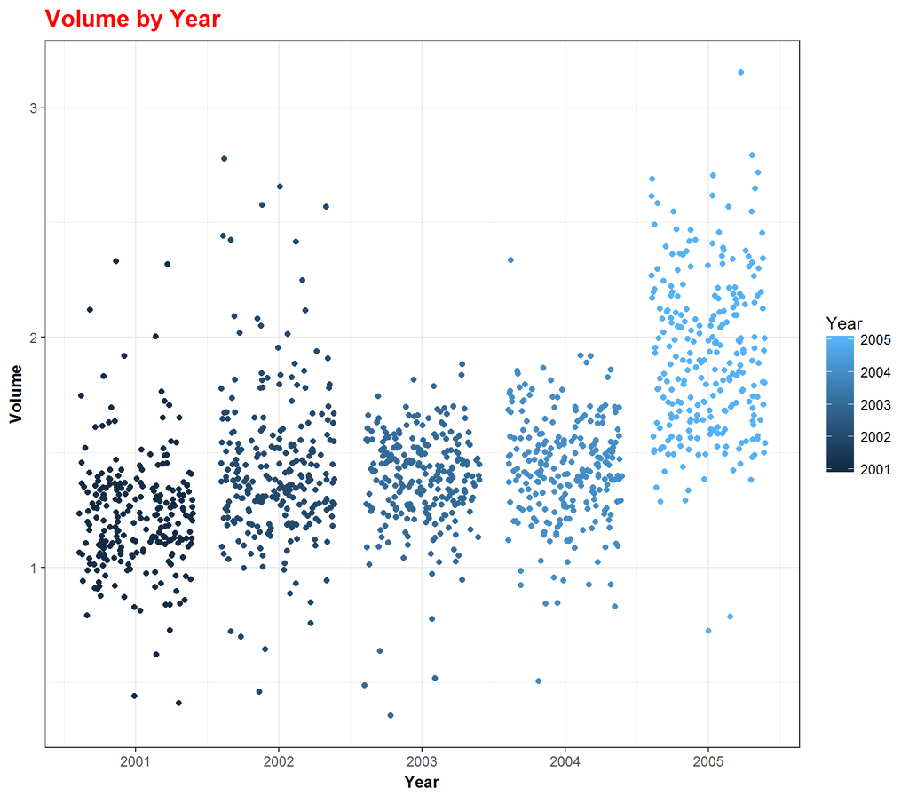

```r
Smarket %>% ggplot(aes(x = Year, y = Volume)) +
            geom_jitter(aes(col = Year)) +
            ggtitle("Volume by Year") +
            theme_bw() +
            theme(plot.title = element_text(size = 15, face = "bold", color = "red")) +
            theme(axis.title.x = element_text(size = 10, face = "bold")) +
            theme(axis.title.y = element_text(size = 10, face = "bold"))
```

```r
#anova
attach(Smarket)
yy <- as.factor(Year)
aov(Volume ~ yy, Smarket) %>% TukeyHSD()
```

```
##   Tukey multiple comparisons of means
##     95% family-wise confidence level
##
## Fit: aov(formula = Volume ~ yy, data = Smarket)
##
## $yy
##                   diff         lwr        upr     p adj
## 2002-2001  0.201501885  0.13366915 0.26933462 0.0000000
## 2003-2001  0.157743551  0.08991081 0.22557629 0.0000000
## 2004-2001  0.197209028  0.12937629 0.26504177 0.0000000
## 2005-2001  0.690348591  0.62251585 0.75818133 0.0000000
## 2003-2002 -0.043758333 -0.11090100 0.02338433 0.3855106
## 2004-2002 -0.004292857 -0.07143552 0.06284981 0.9997918
## 2005-2002  0.488846706  0.42170404 0.55598937 0.0000000
## 2004-2003  0.039465476 -0.02767719 0.10660814 0.4939491
## 2005-2003  0.532605040  0.46546238 0.59974770 0.0000000
## 2005-2004  0.493139563  0.42599690 0.56028223 0.0000000
```

Nhìn vào biểu đồ và kiểm định ANOVA ta thấy số cổ phần được bán mỗi ngày có xu hướng tăng từ 2001 đến các năm 2002->2005; từ 2002 đến 2005; từ 2003 đến 2005; từ 2004 đến với 2005. Còn trong các năm 2002->2004 sự khác biệt là không đáng kể.

## 2.2 Xây dựng mô hình

```r
#create a dummy variable
contrasts(Direction)
```

```
##      Up
## Down  0
## Up    1
```

Ta đặt biến giả để biểu diễn biến phụ thuộc - xu hướng hiện tại của thị trường (Direction). Direction nhận 2 giá trị:

- Direction = 1 - thị trường đi lên
- Direction = 0 - thị trường đi xuống

pi = P(Direction=1/Lag1,…,Lag5,Volume) - xác suất thị trường có xu hướng đi lên

(1-pi) = P(Direction=0/Lag1,…,Lag5,Volume) - xác suất thị trường có xu hướng đi xuống

```r
#logistic regression model
glm.fit <- glm(Direction ~ Lag1 + Lag2 + Lag3 + Lag4 + Lag5 + Volume,
               data = Smarket,
               family = binomial)
glm.fit %>% summary
```

```
##
## Call:
## glm(formula = Direction ~ Lag1 + Lag2 + Lag3 + Lag4 + Lag5 +
##     Volume, family = binomial, data = Smarket)
##
## Deviance Residuals:
##    Min      1Q  Median      3Q     Max
## -1.446  -1.203   1.065   1.145   1.326
##
## Coefficients:
##              Estimate Std. Error z value Pr(>|z|)
## (Intercept) -0.126000   0.240736  -0.523    0.601
## Lag1        -0.073074   0.050167  -1.457    0.145
## Lag2        -0.042301   0.050086  -0.845    0.398
## Lag3         0.011085   0.049939   0.222    0.824
## Lag4         0.009359   0.049974   0.187    0.851
## Lag5         0.010313   0.049511   0.208    0.835
## Volume       0.135441   0.158360   0.855    0.392
##
## (Dispersion parameter for binomial family taken to be 1)
##
##     Null deviance: 1731.2  on 1249  degrees of freedom
## Residual deviance: 1727.6  on 1243  degrees of freedom
## AIC: 1741.6
##
## Number of Fisher Scoring iterations: 3
```

Ta dùng mô hình hồi quy Logistic để dự báo xu hướng hiện tại của thị trường (Direction) sử dụng các biến độc lập Lag1,…, Lag5 và Volume.

Ta thấy p-value với biến Lag1 (% lợi tức của ngày hôm trước) là nhỏ nhất (=0.145). Beta1 ~ -0.07307<0, tức xác suất thị trường đi lên trong ngày hiện tại tỷ lệ nghịch với % lợi tức của ngày hôm trước (Lag1). Nói cách khác, nếu thị trường ngày hôm trước đi lên thì thị trường ngày hôm nay sẽ ít có khả năng đi lên (xác suất thị trường đi lên trong ngày hiện tại thấp hơn xác suất thị trường đi xuống). Nhưng p-value = 0.145 là tương đối lớn (>0.05) nên không thể khẳng định rõ ràng về mối liên hệ thực sự giữa % lợi tức của ngày hôm trước và xu hướng thị trường ngày hiện tại (Beta1 không có ý nghĩa về mặt thống kê).

```r
lrm(Direction ~ Lag1 + Lag2 + Lag3 + Lag4 + Lag5 + Volume)
```

```
## Logistic Regression Model
##
##  lrm(formula = Direction ~ Lag1 + Lag2 + Lag3 + Lag4 + Lag5 +
##      Volume)
##
##                       Model Likelihood     Discrimination    Rank Discrim.
##                          Ratio Test           Indexes           Indexes
##  Obs          1250    LR chi2      3.59    R2       0.004    C       0.538
##   Down         602    d.f.            6    g        0.118    Dxy     0.076
##   Up           648    Pr(> chi2) 0.7319    gr       1.125    gamma   0.078
##  max |deriv| 1e-13                         gp       0.029    tau-a   0.038
##                                            Brier    0.249
##
##            Coef    S.E.   Wald Z Pr(>|Z|)
##  Intercept -0.1260 0.2407 -0.52  0.6007
##  Lag1      -0.0731 0.0502 -1.46  0.1452
##  Lag2      -0.0423 0.0501 -0.84  0.3984
##  Lag3       0.0111 0.0499  0.22  0.8243
##  Lag4       0.0094 0.0500  0.19  0.8514
##  Lag5       0.0103 0.0495  0.21  0.8350
##  Volume     0.1354 0.1584  0.86  0.3924
##
```

**Pseudo R squared** Là hệ số (nhận giá trị từ 0 đến 1) cho biết mức độ giải thích sự thay đổi của biến phụ thuộc bởi các biến độc lập trong mô hình hồi quy Logistic, tương tự như R squared trong OLS. Pseudo R squared càng cao thì mức độ giải thích sự thay đổi của biến phụ thuộc bởi các biến độc lập trong mô hình càng cao.

$$pseudo.R^2 = 1-\frac{residual.deviance}{null.deviance}$$

Pseudo R squared trong mô hình này ~ 0 chứng tỏ các biến độc lập gần như không giải thích được gì sự thay đổi của biến phụ thuộc (Direction).

## 2.3 Dự báo xu hướng thị trường & đánh giá chất lượng mô hình

```r
#predict the probability that the market will go up
glm.probs <- predict(glm.fit, type = "response")

#classification: up/down
glm.pred <- rep("Down", 1250)    #create a vector of 1250 "Down" elements
glm.pred[glm.probs >.5] <- "Up"    #prob > 0.5 -> "Up"

#confusion matrix
table(glm.pred, Direction)
```

```
##         Direction
## glm.pred Down  Up
##     Down  145 141
##     Up    457 507
```

Ta dự báo xác suất thị trường đi lên trong ngày hiện tại, sau đó ta sẽ chọn ngưỡng 0.5 để phân loại:

- Nhóm có xác suất > 0.5 - thị trường có xu hướng đi lên (“Up”)
- Nhóm còn lại - thị trường có xu hướng đi xuống (“Down”)

Ta thấy số ngày thị trường đi xuống được dự báo đúng là 145 ngày, số ngày thị trường đi lên được dự báo đúng là 507 ngày. Vậy tổng số ngày dự báo đúng xu hướng thị trường là: 145+507=652 ngày.

```r
#% correct classification
mean(glm.pred == Direction)
```

```
## [1] 0.5216
```

% phân loại (hay dự báo) đúng xu hướng thị trường là 52.16%. Tuy nhiên, kết quả trên có thể thiếu chính xác do chúng ta xây dựng mô hình và đánh giá chất lượng mô hình với cùng 1 mẫu quan sát (% lợi tức của S&P 500 trong 1250 ngày từ 2001 đến 2005).

Để đánh giá chính xác hơn về chất lượng của mô hình hồi quy Logistic, ta chia bộ dữ liệu “Smarket” thành hai phần. Phần thứ nhất là dữ liệu huấn luyện (**Training Set**) gồm 998 quan sát từ năm 2001 đến 2004 để xây dựng mô hình. Phần còn lại là dữ liệu kiểm định (**Testing Set**) gồm 252 quan sát trong năm 2005 dùng để đánh giá chất lượng của mô hình thu được. Để cải thiện khả năng dự báo của mô hình, biến độc lập ta sẽ chỉ lấy Lag1, Lag2 - hai biến có ảnh hưởng tới biến phụ thuộc (Direction) hơn các biến còn lại.

```r
#Smarket: Year before 2005 - 998 obs
Smarket.before2005 <- Smarket %>% filter(Year < 2005)

#Smarket: Year 2005 - 252 obs
Smarket.2005 <- Smarket %>% filter(Year == 2005)

#logistic regression model  (using 998 obs from 2001 to 2004)
glm.fit3 <- glm(Direction ~ Lag1 + Lag2,
                data = Smarket.before2005,
                family = binomial)
glm.fit3 %>% summary
```

```
##
## Call:
## glm(formula = Direction ~ Lag1 + Lag2, family = binomial, data = Smarket.before2005)
##
## Deviance Residuals:
##    Min      1Q  Median      3Q     Max
## -1.345  -1.188   1.074   1.164   1.326
##
## Coefficients:
##             Estimate Std. Error z value Pr(>|z|)
## (Intercept)  0.03222    0.06338   0.508    0.611
## Lag1        -0.05562    0.05171  -1.076    0.282
## Lag2        -0.04449    0.05166  -0.861    0.389
##
## (Dispersion parameter for binomial family taken to be 1)
##
##     Null deviance: 1383.3  on 997  degrees of freedom
## Residual deviance: 1381.4  on 995  degrees of freedom
## AIC: 1387.4
##
## Number of Fisher Scoring iterations: 3
```

```r
#predict the probability that the market will go up  (using 252 obs in 2005)
glm.probs3 <- predict(glm.fit3, Smarket.2005, type = "response")

#classification: up/down  (using 252 obs in 2005)
glm.pred3 = rep ("Down", 252)
glm.pred3[glm.probs3 >.5] = "Up"

#confusion matrix
Direction.2005 <- Direction[Year == 2005]
table(glm.pred3, Direction.2005)
```

```
##          Direction.2005
## glm.pred3 Down  Up
##      Down   35  35
##      Up     76 106
```

```r
#% correct classification
mean(glm.pred3 == Direction.2005)
```

```
## [1] 0.5595238
```

Ta nhận thấy % phân loại đúng xu hướng thị trường đã tăng lên so với mô hình gốc ban đầu (56% so với 52% lúc trước). Trong khi đó nhìn vào confusion matrix ta thấy trong tổng số ngày được dự báo là thị trường đi lên có 106/(106+76) ~ 58% được dự báo đúng.

**ROC curves**

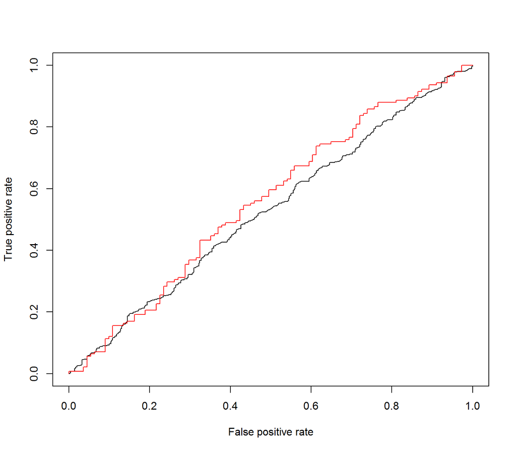

```r
# ROC curves on training test and testing set
pred_train <- predict(glm.fit3, Smarket.before2005, type = "response")

pred_test <- predict(glm.fit3, Smarket.2005, type = "response")

ROCpred_train <- prediction(pred_train, Smarket.before2005$Direction) #transform the input data into a standardized format

ROCpred_test <- prediction(pred_test, Smarket.2005$Direction)

ROCperf_train <- performance(ROCpred_train, "tpr", "fpr")

ROCperf_test <- performance(ROCpred_test, "tpr", "fpr")

plot(ROCperf_train)

plot(ROCperf_test, col = "red", add =T)
```

**AUC**

```r
auc_train <- performance(ROCpred_train, "auc", "cutoff")
auc_train@y.values
```

```
## [[1]]
## [1] 0.5266714
```

```r
auc_test <- performance(ROCpred_test, "auc", "cutoff")
auc_test@y.values
```

```
## [[1]]
## [1] 0.5584308
```

**GAIN charts**

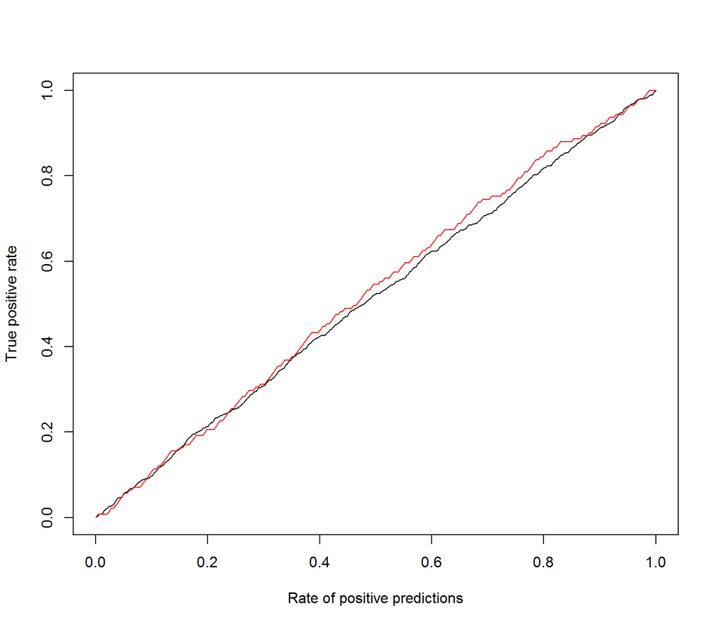

```r
# GAIN charts on training test and testing set
GAINperf_train <- performance(ROCpred_train, "tpr", "rpp")

GAINperf_test <- performance(ROCpred_test, "tpr", "rpp")

plot(GAINperf_train)

plot(GAINperf_test, col = "red", add =T)
```

Rate of positive predictions (RPP): tỷ lệ tổng số quan sát được dự báo là Y=1 (“Up”) trên tổng số quan sát.

**LIFT charts**

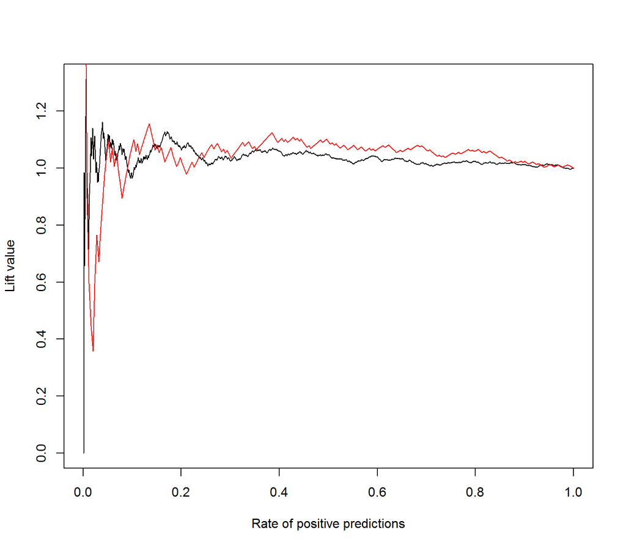

```r
# LIFT charts on training test and testing set
LIFTperf_train <- performance(ROCpred_train, "lift", "rpp")

LIFTperf_test <- performance(ROCpred_test, "lift", "rpp")

plot(LIFTperf_train)

plot(LIFTperf_test, col = "red", add =T)
```

Lift value = TPR/RPP.

# 3 Những thông tin thêm

## 3.1 Biến độc lập là biến định tính

Trong trường hợp biến độc lập là biến định tính có 2 phạm trù, có thể sử dụng 1 biến giả 0-1 để biểu diễn thông tin định tính này. Khi biến độc lập là biến định tính có m phạm trù (m>2), cần (m-1) biến giả 0-1.

Ví dụ, biến “loại hình doanh nghiệp” có 3 phạm trù: nhà nước, tư nhân, FDI. Có thể sử dụng 2 biến giả sau:

- NN: NN=1 - doanh nghiệp nhà nước, NN=0 - không phải doanh nghiệp nhà nước
- TN: TN=1 - doanh nghiệp tư nhân, TN=0 - không phải doanh nghiệp tư nhân

Như vậy, các doanh nghiệp nhà nước sẽ ứng với (NN=1, TN=0), doanh nghiệp tư nhân (NN=0, TN=1), doanh nghiệp FDI (NN=0, TN=0). Nhóm “doanh nghiệp FDI” được gọi là **phạm trù cơ sở** - phạm trù ứng với trường hợp tất cả các biến giả nhận giá trị 0.

## 3.2 WoE & IV

### 3.2.1 Khái niệm

WoE (**Weight of Evidence**) miêu tả mối quan hệ giữa biến độc lập và biến phụ thuộc theo categories (phạm trù) của biến phụ thuộc. Còn IV (**Infomation Value**) đo lường độ mạnh của mối quan hệ đó.

Diễn giải một cách chi tiết, giả sử biến phụ thuộc - KH có 2 categories (phạm trù): Good (KH=1) & Bad (KH=0). Biến độc lập - Tuổi nhận các giá trị khác nhau: 16,20,21,32… WoE sẽ giúp ta chia biến Tuổi thành các nhóm (bins/groups) (ví dụ: <22; 22-25; 25-30; 30-40; 40-50; >50). Ứng với mỗi nhóm tuổi sẽ có số lượng KH good/bad nhất định và giá trị WoE tương ứng.

Công thức tính WoE:
$$WoE=ln(\frac{Distr. Goods}{Distr. Bads})$$
Trong đó:
$$Distr.Goods = \frac{Goods}{Total - of - Goods}$$
$$Distr.Bads = \frac{Bads}{Total - of - Bads}$$
Sẽ có 3 trường hợp:

- WoE = 0 khi Distr.Goods = Distr.Bads
- WoE < 0 khi Distr.Goods < Distr.Bads
- WoE > 0 khi Distr.Goods > Distr.Bads

Công thức tính IV:
$$IV=\sum[(Distr.Goods_i - Distr.Bads_i)*WoE_i] ; i=1,..,n$$

- IV < 0.02: biến độc lập không có ý nghĩa trong mô hình (để phân chia Good/Bad biến phụ thuộc)
- 0.02 - 0.1: biến độc lập có mối liên hệ yếu với biến phụ thuộc - weak relationship
- 0.1 - 0.3: medium relationship
- trên 0.3: strong relationship

### 3.2.2 Ví dụ

Ta xem ví dụ sau:

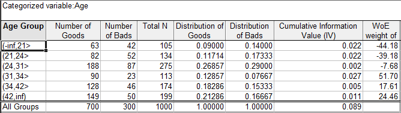

Ở nhóm tuổi 21-24: có 82 Goods (KH tốt), 52 Bads (KH xấu). Tổng số KH tốt của tất cả các nhóm tuổi là 700, KH xấu - 300.

=> Distr.Goods = 82/700 ~ 0.11714; Distr.Bads = 52/300 ~ 0.17333

WoE = ln(0.11714/0.17333) ~ -0.3918;

Cumulative IV tương ứng với nhóm tuổi trên = (0.11714-0.17333)*(-0.3918) = 0.0220.

=> IV = tổng Cumulative IV của từng nhóm tuổi = 0.089 - biến độc lập (Tuổi) có mối liện hệ “yếu” với biến phụ thuộc.

### 3.2.3 Thực hành trong R

Trong R có khá nhiều package dùng để tính WoE và IV như: “Information”, “woe”, “riv”, “smbinning” v.v.

Ở đây ta sẽ sử dụng một trong số đó để thực hành - **“smbinning”** package

**Số liệu thực hành**:

Dùng bộ số liệu “chileancredit” trong R

```r
# Load smbinning sample dataset (Chilean Credit)
data(chileancredit)

# Quick description of the data
str(chileancredit)
```

```
## 'data.frame':    7702 obs. of  19 variables:
##  $ CustomerId       : chr  "0000000185" "0000000238" "0000000346" "0000000460" ...
##  $ TOB              : int  44 79 102 NA 109 183 172 76 136 171 ...
##  $ IncomeLevel      : Factor w/ 6 levels "0","1","2","3",..: 2 2 2 2 NA NA 1 2 1 1 ...
##  $ Bal01            : num  605 1006 299 645 218 ...
##  $ MaxDqBin01       : Factor w/ 7 levels "0","1","2","3",..: 1 1 1 1 1 1 1 1 1 1 ...
##  $ MaxDqBin02       : Factor w/ 8 levels "0","1","2","3",..: 1 1 1 1 1 1 1 1 1 1 ...
##  $ MaxDqBin03       : Factor w/ 8 levels "0","1","2","3",..: 1 1 1 1 1 1 1 2 1 1 ...
##  $ MaxDqBin04       : Factor w/ 8 levels "0","1","2","3",..: 1 1 1 1 1 1 1 1 1 1 ...
##  $ MaxDqBin05       : Factor w/ 8 levels "0","1","2","3",..: 1 1 1 1 1 1 1 1 1 1 ...
##  $ MaxDqBin06       : Factor w/ 8 levels "0","1","2","3",..: 1 1 1 1 1 1 1 1 1 1 ...
##  $ MtgBal01         : num  0 0 0 0 0 0 0 0 0 0 ...
##  $ NonBankTradesDq01: int  0 0 0 0 0 0 0 0 0 0 ...
##  $ NonBankTradesDq02: int  0 0 0 0 0 0 0 0 0 0 ...
##  $ NonBankTradesDq03: int  0 0 0 0 0 0 0 0 0 0 ...
##  $ NonBankTradesDq04: int  0 0 0 0 0 0 0 1 0 0 ...
##  $ NonBankTradesDq05: int  0 0 0 0 0 0 0 1 0 0 ...
##  $ NonBankTradesDq06: int  0 0 0 0 0 0 0 1 0 0 ...
##  $ FlagGB           : int  1 1 1 1 1 1 1 1 1 1 ...
##  $ FlagSample       : int  1 1 1 1 1 1 1 1 1 1 ...
```

```r
summary(chileancredit)
```

```
##   CustomerId             TOB        IncomeLevel     Bal01
##  Length:7702        Min.   :  0.0   0   :2532   Min.   :     0.0
##  Class :character   1st Qu.: 12.0   1   :3315   1st Qu.:   320.2
##  Mode  :character   Median : 34.0   2   : 380   Median :  1110.1
##                     Mean   : 50.2   3   : 696   Mean   :  3264.0
##                     3rd Qu.: 76.0   4   : 337   3rd Qu.:  3319.2
##                     Max.   :255.0   5   :  76   Max.   :124102.1
##                     NA's   :777     NA's: 366
##  MaxDqBin01   MaxDqBin02     MaxDqBin03     MaxDqBin04     MaxDqBin05
##  0:6846     0      :6578   0      :6530   0      :6507   0      :6413
##  1: 513     1      : 533   1      : 537   1      : 512   1      : 527
##  2: 153     2      : 169   2      : 153   2      : 124   2      : 122
##  3: 127     3      :  72   3      :  56   7      :  48   7      :  43
##  4:  31     7      :  68   7      :  56   3      :  36   3      :  29
##  5:  19     (Other):  48   (Other):  43   (Other):  36   (Other):  37
##  6:  13     NA's   : 234   NA's   : 327   NA's   : 439   NA's   : 531
##    MaxDqBin06      MtgBal01      NonBankTradesDq01  NonBankTradesDq02
##  0      :6362   Min.   :     0   Min.   :  0.0000   Min.   :  0.0000
##  1      : 519   1st Qu.:     0   1st Qu.:  0.0000   1st Qu.:  0.0000
##  2      :  98   Median :     0   Median :  0.0000   Median :  0.0000
##  7      :  38   Mean   :  5121   Mean   :  0.8093   Mean   :  0.7294
##  3      :  30   3rd Qu.:     0   3rd Qu.:  0.0000   3rd Qu.:  0.0000
##  (Other):  32   Max.   :829719   Max.   :289.0000   Max.   :289.0000
##  NA's   : 623
##  NonBankTradesDq03  NonBankTradesDq04  NonBankTradesDq05
##  Min.   :  0.0000   Min.   :  0.0000   Min.   :  0.00
##  1st Qu.:  0.0000   1st Qu.:  0.0000   1st Qu.:  0.00
##  Median :  0.0000   Median :  0.0000   Median :  0.00
##  Mean   :  0.6729   Mean   :  0.6269   Mean   :  0.58
##  3rd Qu.:  0.0000   3rd Qu.:  0.0000   3rd Qu.:  0.00
##  Max.   :289.0000   Max.   :289.0000   Max.   :289.00
##
##  NonBankTradesDq06      FlagGB         FlagSample
##  Min.   :  0.0000   Min.   :0.0000   Min.   :0.0000
##  1st Qu.:  0.0000   1st Qu.:1.0000   1st Qu.:1.0000
##  Median :  0.0000   Median :1.0000   Median :1.0000
##  Mean   :  0.5392   Mean   :0.8989   Mean   :0.7531
##  3rd Qu.:  0.0000   3rd Qu.:1.0000   3rd Qu.:1.0000
##  Max.   :288.0000   Max.   :1.0000   Max.   :1.0000
##                     NA's   :1412
```

```r
# Tabulate target variable
table(chileancredit$FlagGB)
```

```
##
##    0    1
##  636 5654
```

```r
# Training and testing samples
chileancredit.train <- chileancredit %>%  filter(FlagSample == 1)
chileancredit.test  <- chileancredit %>%  filter(FlagSample == 0)

# Run and save result
result <- smbinning(df = chileancredit.train,
                    y = "FlagGB",
                    x = "TOB",
                    p = 0.05)
result
```

```
## $ivtable
##   Cutpoint CntRec CntGood CntBad CntCumRec CntCumGood CntCumBad PctRec
## 1    <= 17   1138     909    229      1138        909       229 0.2405
## 2    <= 30    621     530     91      1759       1439       320 0.1312
## 3    <= 63   1064     985     79      2823       2424       399 0.2249
## 4     > 63   1427    1377     50      4250       3801       449 0.3016
## 5  Missing    482     435     47      4732       4236       496 0.1019
## 6    Total   4732    4236    496        NA         NA        NA 1.0000
##   GoodRate BadRate    Odds LnOdds     WoE     IV
## 1   0.7988  0.2012  3.9694 1.3786 -0.7662 0.1893
## 2   0.8535  0.1465  5.8242 1.7620 -0.3828 0.0223
## 3   0.9258  0.0742 12.4684 2.5232  0.3784 0.0277
## 4   0.9650  0.0350 27.5400 3.3156  1.1708 0.2626
## 5   0.9025  0.0975  9.2553 2.2252  0.0804 0.0006
## 6   0.8952  0.1048  8.5403 2.1448  0.0000 0.5025
##
## $iv
## [1] 0.5025
##
## $ctree
##
## Model formula:
## FlagGB ~ TOB
##
## Fitted party:
## [1] root
## |   [2] TOB <= 30
## |   |   [3] TOB <= 17: 0.799 (n = 1138, err = 182.9)
## |   |   [4] TOB > 17: 0.853 (n = 621, err = 77.7)
## |   [5] TOB > 30
## |   |   [6] TOB <= 63: 0.926 (n = 1064, err = 73.1)
## |   |   [7] TOB > 63: 0.965 (n = 1427, err = 48.2)
##
## Number of inner nodes:    3
## Number of terminal nodes: 4
##
## $bands
## [1]   0  17  30  63 255
##
## $x
## [1] "TOB"
##
## $col_id
## [1] 2
##
## $cuts
## [1] 17 30 63
```

IV của TOB ở đây bằng 0.5025 - chứng tỏ biến độc lập TOB có mối liên hệ “mạnh” với biến phụ thuộc (FlagGB). Ngoài ra, nhìn vào $ivtable ta thấy biến TOB được chia thành 5 nhóm (5 Cutpoint). Trong các nhóm đó có nhóm khuyết dữ liệu (Missing), và ta muốn gộp nhóm đó vào nhóm mà có giá trị WoE gần nhất với giá trị WoE của nhóm Missing.

```r
attach(result)
attach(ivtable)
a <- 1:length(Cutpoint)        #a- stt của Cutpoint
b <- a[Cutpoint == "Missing"]  #b- stt của Missing Cutpoint

d = c()
for (i in 1:(b-1))           #i- stt của WoE
 {
 d[i] = abs(WoE[i] - WoE[Cutpoint == "Missing"])   #d- chênh lệch giữa WoE của nhóm Missing và các nhóm khác
 }

index_d <- 1:length(d)       #index_d- stt của d

d <- as.data.frame(d)
d$index_d <- index_d

e <- index_d[d$d == min(d$d)]  #e- stt của min(d)

#chuyển Cutpoint mang giá trị Missing thành <=63 (WoE của Cutpoint Missing gần nhất với WoE của Cutpoint <=63)
ivtable$Cutpoint[ivtable$Cutpoint == "Missing"] <- ivtable$Cutpoint[e]

#tổng hợp dữ liệu theo Cutpoint
aggregate(ivtable[,2:14],
          by = list(ivtable$Cutpoint),
          sum)
```

```
##   Group.1 CntRec CntGood CntBad CntCumRec CntCumGood CntCumBad PctRec
## 1   <= 17   1138     909    229      1138        909       229 0.2405
## 2   <= 30    621     530     91      1759       1439       320 0.1312
## 3   <= 63   1546    1420    126      7555       6660       895 0.3268
## 4    > 63   1427    1377     50      4250       3801       449 0.3016
## 5   Total   4732    4236    496        NA         NA        NA 1.0000
##   GoodRate BadRate    Odds LnOdds     WoE     IV
## 1   0.7988  0.2012  3.9694 1.3786 -0.7662 0.1893
## 2   0.8535  0.1465  5.8242 1.7620 -0.3828 0.0223
## 3   1.8283  0.1717 21.7237 4.7484  0.4588 0.0283
## 4   0.9650  0.0350 27.5400 3.3156  1.1708 0.2626
## 5   0.8952  0.1048  8.5403 2.1448  0.0000 0.5025
```

Như vậy TOB sẽ chỉ chia thành 4 nhóm: <=17; <=30; <=63; >63 (ta gộp nhóm “Missing” vào nhóm “<=63”).

```r
a <- smbinning.sumiv(df = chileancredit, y = "FlagGB")  #IV for all independent variables
a
```

```
##                 Char     IV                  Process
## 5         MaxDqBin01 2.2982        Factor binning OK
## 12 NonBankTradesDq01 1.7649       Numeric binning OK
## 6         MaxDqBin02 1.6948        Factor binning OK
## 13 NonBankTradesDq02 1.3913       Numeric binning OK
## 7         MaxDqBin03 1.3000        Factor binning OK
## 14 NonBankTradesDq03 1.1100       Numeric binning OK
## 8         MaxDqBin04 1.0078        Factor binning OK
## 15 NonBankTradesDq04 0.8726       Numeric binning OK
## 9         MaxDqBin05 0.8319        Factor binning OK
## 16 NonBankTradesDq05 0.6930       Numeric binning OK
## 10        MaxDqBin06 0.6302        Factor binning OK
## 2                TOB 0.5055       Numeric binning OK
## 17 NonBankTradesDq06 0.5011       Numeric binning OK
## 3        IncomeLevel 0.3018        Factor binning OK
## 11          MtgBal01 0.1228       Numeric binning OK
## 1         CustomerId     NA   Not numeric nor factor
## 4              Bal01     NA    No significant splits
## 18        FlagSample     NA Uniques values of x < 10
```

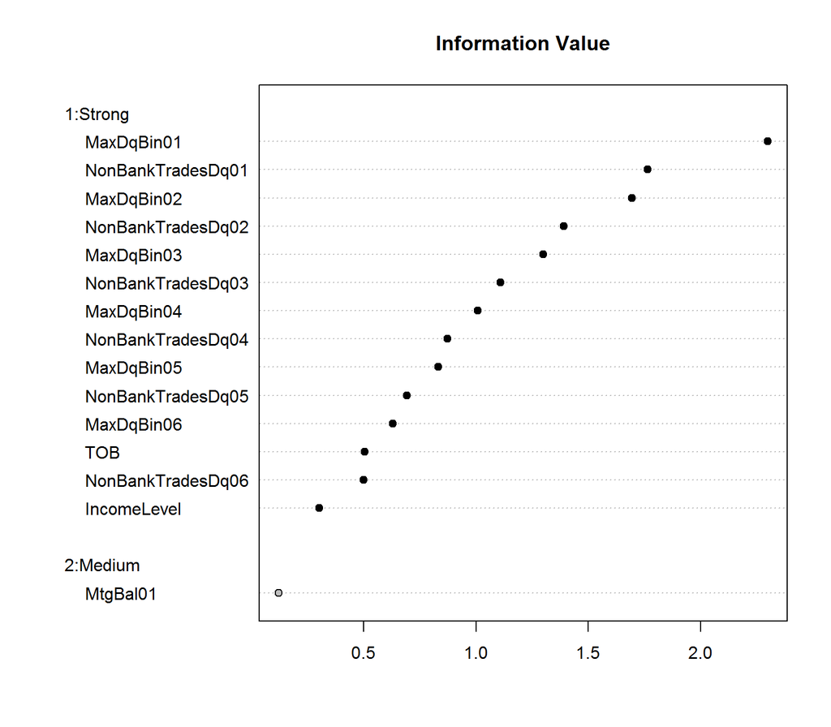

```r
smbinning.sumiv.plot(a,cex=1)
```

Ta thấy biến MtgBal01 có mối liên hệ “trung bình” với biến FlagGB (0.1 < IV=0.1228 < 0.3), còn các biến khác được liệt kê ở trên có mối liên hệ “mạnh” với biến FlagGB (IV > 0.3).

**Lưu ý**

Khi sử dụng “smbinning” package, ta cần phải thu thập và xử lý số liệu sao cho:

- Biến phụ thuộc chỉ nhận 2 giá trị 0-1, định dạng cần phải là integer (int)
- Biến độc lập cần phải có ít nhất 10 giá trị khác nhau, định dạng cần phải là numeric hoặc factor.

## 3.3 Cách chọn mô hình tối ưu

**Forward**

```r
M_intercept <- glm(Direction ~ 1,
                   data = Smarket,
                   family = binomial)
#forward
step(M_intercept,
     scope = list(lower = M_intercept, upper = glm.fit),
     direction = "forward")
```

```
## Start:  AIC=1733.17
## Direction ~ 1
##
##          Df Deviance    AIC
## <none>        1731.2 1733.2
## + Lag1    1   1729.2 1733.2
## + Lag2    1   1730.5 1734.5
## + Volume  1   1730.5 1734.5
## + Lag3    1   1731.1 1735.1
## + Lag5    1   1731.1 1735.1
## + Lag4    1   1731.2 1735.2
```

```
##
## Call:  glm(formula = Direction ~ 1, family = binomial, data = Smarket)
##
## Coefficients:
## (Intercept)
##     0.07363
##
## Degrees of Freedom: 1249 Total (i.e. Null);  1249 Residual
## Null Deviance:       1731
## Residual Deviance: 1731  AIC: 1733
```

**Backward**

```r
#backward
step(glm.fit, direction = "backward")
```

```
## Start:  AIC=1741.58
## Direction ~ Lag1 + Lag2 + Lag3 + Lag4 + Lag5 + Volume
##
##          Df Deviance    AIC
## - Lag4    1   1727.6 1739.6
## - Lag5    1   1727.6 1739.6
## - Lag3    1   1727.6 1739.6
## - Lag2    1   1728.3 1740.3
## - Volume  1   1728.3 1740.3
## <none>        1727.6 1741.6
## - Lag1    1   1729.7 1741.7
##
## Step:  AIC=1739.62
## Direction ~ Lag1 + Lag2 + Lag3 + Lag5 + Volume
##
##          Df Deviance    AIC
## - Lag5    1   1727.7 1737.7
## - Lag3    1   1727.7 1737.7
## - Volume  1   1728.3 1738.3
## - Lag2    1   1728.3 1738.3
## <none>        1727.6 1739.6
## - Lag1    1   1729.8 1739.8
##
## Step:  AIC=1737.66
## Direction ~ Lag1 + Lag2 + Lag3 + Volume
##
##          Df Deviance    AIC
## - Lag3    1   1727.7 1735.7
## - Volume  1   1728.4 1736.4
## - Lag2    1   1728.4 1736.4
## <none>        1727.7 1737.7
## - Lag1    1   1729.8 1737.8
##
## Step:  AIC=1735.71
## Direction ~ Lag1 + Lag2 + Volume
##
##          Df Deviance    AIC
## - Volume  1   1728.4 1734.4
## - Lag2    1   1728.4 1734.4
## <none>        1727.7 1735.7
## - Lag1    1   1729.8 1735.8
##
## Step:  AIC=1734.4
## Direction ~ Lag1 + Lag2
##
##        Df Deviance    AIC
## - Lag2  1   1729.2 1733.2
## <none>      1728.4 1734.4
## - Lag1  1   1730.5 1734.5
##
## Step:  AIC=1733.2
## Direction ~ Lag1
##
##        Df Deviance    AIC
## - Lag1  1   1731.2 1733.2
## <none>      1729.2 1733.2
##
## Step:  AIC=1733.17
## Direction ~ 1
```

```
##
## Call:  glm(formula = Direction ~ 1, family = binomial, data = Smarket)
##
## Coefficients:
## (Intercept)
##     0.07363
##
## Degrees of Freedom: 1249 Total (i.e. Null);  1249 Residual
## Null Deviance:       1731
## Residual Deviance: 1731  AIC: 1733
```

**Stepwise**

```r
#stepwise
step(glm.fit, direction = "both")
```

```
## Start:  AIC=1741.58
## Direction ~ Lag1 + Lag2 + Lag3 + Lag4 + Lag5 + Volume
##
##          Df Deviance    AIC
## - Lag4    1   1727.6 1739.6
## - Lag5    1   1727.6 1739.6
## - Lag3    1   1727.6 1739.6
## - Lag2    1   1728.3 1740.3
## - Volume  1   1728.3 1740.3
## <none>        1727.6 1741.6
## - Lag1    1   1729.7 1741.7
##
## Step:  AIC=1739.62
## Direction ~ Lag1 + Lag2 + Lag3 + Lag5 + Volume
##
##          Df Deviance    AIC
## - Lag5    1   1727.7 1737.7
## - Lag3    1   1727.7 1737.7
## - Volume  1   1728.3 1738.3
## - Lag2    1   1728.3 1738.3
## <none>        1727.6 1739.6
## - Lag1    1   1729.8 1739.8
## + Lag4    1   1727.6 1741.6
##
## Step:  AIC=1737.66
## Direction ~ Lag1 + Lag2 + Lag3 + Volume
##
##          Df Deviance    AIC
## - Lag3    1   1727.7 1735.7
## - Volume  1   1728.4 1736.4
## - Lag2    1   1728.4 1736.4
## <none>        1727.7 1737.7
## - Lag1    1   1729.8 1737.8
## + Lag5    1   1727.6 1739.6
## + Lag4    1   1727.6 1739.6
##
## Step:  AIC=1735.71
## Direction ~ Lag1 + Lag2 + Volume
##
##          Df Deviance    AIC
```

[output cut: 28 more lines]

```
## + Lag3    1   1729.2 1735.2
## + Lag5    1   1729.2 1735.2
## + Lag4    1   1729.2 1735.2
##
## Step:  AIC=1733.17
## Direction ~ 1
##
##          Df Deviance    AIC
## <none>        1731.2 1733.2
## + Lag1    1   1729.2 1733.2
## + Lag2    1   1730.5 1734.5
## + Volume  1   1730.5 1734.5
## + Lag3    1   1731.1 1735.1
## + Lag5    1   1731.1 1735.1
## + Lag4    1   1731.2 1735.2
```

```
##
## Call:  glm(formula = Direction ~ 1, family = binomial, data = Smarket)
##
## Coefficients:
## (Intercept)
##     0.07363
##
## Degrees of Freedom: 1249 Total (i.e. Null);  1249 Residual
## Null Deviance:       1731
## Residual Deviance: 1731  AIC: 1733
```